# Part one

```python
import numpy as np
import scipy.stats as stats
import matplotlib.pyplot as plt
import pandas as pd

%matplotlib inline
```

```python
p1 = 400/2000
print("Joint probability of the people who planned to purchase and actually placed an order is: %f" %p1)
```

```
Joint probability of the people who planned to purchase and actually placed an order is: 0.200000
```

```python
p2 = 400/500
print("joint probability of the people who planned to purchase and actually placed an order, "
      "given that people planned to purchase is : %f" %p2)
```

```
joint probability of the people who planned to purchase and actually placed an order, given that people planned to purchase is : 0.800000
```

**2. Question:** An electrical manufacturing company conducts quality checks at specified periods on the products it manufactures. Historically, the failure rate for the manufactured item is 5%. Suppose a random sample of 10 manufactured items is selected. Answer the following questions.  
A. Probability that none of the items are defective?  
B. Probability that exactly one of the items is defective?  
C. Probability that two or fewer of the items are defective?  
D. Probability that three or more of the items are defective ?

```python
p_failure = 0.05
p_success = 0.95
n = 10
```

```python
k = np.arange(0,11)

binomial = stats.binom.pmf(k,n,p_failure)

print(binomial)
```

```
[5.98736939e-01 3.15124705e-01 7.46347985e-02 1.04750594e-02
 9.64808106e-04 6.09352488e-05 2.67259863e-06 8.03789063e-08
 1.58642578e-09 1.85546875e-11 9.76562500e-14]
```

```python
#A. Probability that none of the items are defective?

print("A. Probability that none of the item is defective is: %f" %binomial[0])

# Also calculating with the formula
p_0 = 1 * 1 * 0.95**10
p_0
```

```
A. Probability that none of the item is defective is: 0.598737
```

```
0.5987369392383787
```

```python
# B. Probability that exactly one of the items is defective?

print("B. Probability that exactly one of the item is defective: %f" %binomial[1])

#Also calculating with the formula

p_1 = 10 * 0.05 * 0.95**9
p_1
```

```
B. Probability that exactly one of the item is defective: 0.315125
```

```
0.31512470486230454
```

```python
# C. Probability that two or fewer of the items are defective?

print("C. Probability that two or fewer of the items are defective: %f" %(binomial[0]+binomial[1]+binomial[2]))
```

```
C. Probability that two or fewer of the items are defective: 0.988496
```

```python
# D. Probability that three or more of the items are defective ?

print("D. Probability that three or more of the items are defective: %f" %(1 - (binomial[0]+binomial[1]+binomial[2])))
```

```
D. Probability that three or more of the items are defective: 0.011504
```

**3. Question:** A car salesman sells on an average 3 cars per week.  
A. Probability that in a given week he will sell some cars.  
B. Probability that in a given week he will sell 2 or more but less than 5 cars.  
C. Plot the poisson distribution function for cumulative probability of cars sold per-week vs number of cars sold per week.

```python
# a numpy array containing different number of sales ranging from 0 to 10

salesNumber = np.arange(0,11)
lambda_avg = 3
```

```python
poisson = stats.poisson.pmf(salesNumber,lambda_avg)
poisson
```

```
array([0.04978707, 0.14936121, 0.22404181, 0.22404181, 0.16803136,
       0.10081881, 0.05040941, 0.02160403, 0.00810151, 0.0027005 ,
       0.00081015])
```

```python
# A. Probability that in a given week he will sell some cars.
# subtracting probability of zero sale from 1 to get probability of selling some cars

print("A. Probability that in a given week he will sell some cars is: %f" %(1-poisson[0]))
```

```
A. Probability that in a given week he will sell some cars is: 0.950213
```

```python
# B. Probability that in a given week he will sell 2 or more but less than 5 cars.
# Adding probavilities for 2,3 and 4 sales numbers

print("B. Probability that in a given week he will sell 2 or more but less than 5 cars is: %f"
     %(poisson[2] + poisson[3] + poisson[4]))
```

```
B. Probability that in a given week he will sell 2 or more but less than 5 cars is: 0.616115
```

```python
poissonCDF = stats.poisson.cdf(salesNumber, lambda_avg)
poissonCDF
```

```
array([0.04978707, 0.19914827, 0.42319008, 0.64723189, 0.81526324,
       0.91608206, 0.96649146, 0.9880955 , 0.99619701, 0.99889751,
       0.99970766])
```

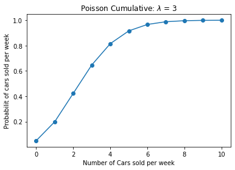

```python
# C. Plot the poisson distribution function for cumulative probability of cars sold per-week vs number of cars sold per week.

plt.plot(salesNumber, poissonCDF, 'o-')
plt.title('Poisson Cumulative: $\lambda$ = %i ' % lambda_avg)
plt.xlabel("Number of Cars sold per week")
plt.ylabel("Probabilit of cars sold per week");
```

**4. Question:** Accuracy in understanding orders for a speech based bot at a restaurant is important for the Company X which has designed, marketed and launched the product for a contactless delivery due to the COVID-19 pandemic. Recognition accuracy that measures the percentage of orders that are taken correctly is 86.8%. Suppose that you place order with the bot and two friends of yours independently place orders with the same bot. Answer the following questions.  
A. What is the probability that all three orders will be recognised correctly?  
B. What is the probability that none of the three orders will be recognised correctly?  
C. What is the probability that at least two of the three orders will be recognised correctly?

```python
p_correct = 0.868
n =3
order_numbers = np.arange(0,4)

binomial_order = stats.binom.pmf(order_numbers, 3,p_correct)
binomial_order
```

```
array([0.00229997, 0.0453721 , 0.2983559 , 0.65397203])
```

```python
binomial_three = 1 * (p_correct**3) * ((1-p_correct)**0)
print(binomial_three)

binomial_none = 1 * (p_correct**0) * ((1-p_correct)**3)
print(binomial_none)

binomial_two = 3 * (p_correct**2) * ((1-p_correct)**1)
print(binomial_two)
```

```
0.653972032
0.0022999680000000003
0.298355904
```

```python
print("A. What is the probability that all three orders will be recognised correctly is: %f" %binomial_order[3])
```

```
A. What is the probability that all three orders will be recognised correctly is: 0.653972
```

```python
print("B. What is the probability that none of the three orders will be recognised correctly is: %f" %binomial_none)
```

```
B. What is the probability that none of the three orders will be recognised correctly is: 0.002300
```

```python
print("C. What is the probability that at least two of the three orders will be recognised correctly is: %f" %binomial_two)
```

[output not shown]

**5. Question:** A group of 300 professionals sat for a competitive exam. The results show the information of marks obtained by them have a mean of 60 and a standard deviation of 12. The pattern of marks follows a normal distribution. Answer the following questions.  
A. What is the percentage of students who score more than 80.  
B. What is the percentage of students who score less than 50.  
C. What should be the distinction mark if the highest 10% of students are to be awarded distinction?

```python
mean_mu = 60
sd_sigma = 12

zScore = (80-mean_mu)/sd_sigma
zScore

p = stats.norm.cdf(zScore)
p
per_moreThan80 = (1-p)*100

#Use the orginal values to calculate the probability
# subtracting from 1 as original value of Zscore will give the percentage who scores till 80
# so, 1 inus that value would gie us students scoring more than 80

1 - stats.norm.cdf(80,loc=60,scale=12)
```

```
0.047790352272814696
```

```python
print("A. the percentage of students who score more than 80 is:  %1.2f"%per_moreThan80,"%")
```

```
A. the percentage of students who score more than 80 is:  4.78 %
```

```python
zScore = (50-mean_mu)/sd_sigma
zScore


p = stats.norm.cdf(zScore)
#As the value or area under the curve is to the left of Zscore, we do not subtract it from 1

per_lessThan50 = p*100
per_lessThan50
```

```
20.232838096364308
```

```python
print("B. the percentage of students who score less than 50 is: %1.2f"%per_lessThan50,"%")
```

```
B. the percentage of students who score less than 50 is: 20.23 %
```

```python
# z score for the 90% cutoff from the normal z score table is 1.28
#z = x-60/12
# where we will substitue z as 1.28
x = (1.28*12)+60
x
```

```
75.36
```

```python
print("C. the distinction mark if the highest 10","%", "of students are to be awarded distinction is: %1.2f" %x, "%")
```

```
C. the distinction mark if the highest 10 % of students are to be awarded distinction is: 75.36 %
```

**6. Question:** Explain 1 real life industry scenario [other than the ones mentioned above] where you can use the concepts learnt in this module of Applied statistics to get a data driven business solution.

## IPL auction example

**Context:** Before IPL, we always have this exciting auction which takes place for the Team owners to select the players in their team. Lets say Team A Owner has the data of all the players that are going to be playing the tournament for that particular year. Based on the data Team A statistical team can come up with the analysis on the Best Players.

**• ATTRIBUTE INFORMATION:**

1. Player Name
2. Mathces - tell about the number of matches playes by that player
3. Inningins
4. NotOuts
5. Runs
6. Highest Score
7. 100s
8. 50s
9. 4s
10. 6s

# Part Two

**CONTEXT:** Company X manages the men's top professional basketball division of the American league system. The dataset contains information on all the teams that have participated in all the past tournaments. It has data about how many baskets each team scored, conceded, how many times they came within the first 2 positions, how many tournaments they have qualified, their best position in the past, etc.

**DATA DESCRIPTION:** Basketball.csv - The data set contains information on all the teams so far participated in all the past tournaments.  
• **ATTRIBUTE INFORMATION:**

1. **Team:** Team’s name
2. **Tournament:** Number of played tournaments.
3. **Score:** Team’s score so far.
4. **PlayedGames:** Games played by the team so far.
5. **WonGames:** Games won by the team so far.
6. **DrawnGames:** Games drawn by the team so far.
7. **LostGames:** Games lost by the team so far.
8. **BasketScored:** Basket scored by the team so far.
9. **BasketGiven:** Basket scored against the team so far. 10.**TournamentChampion:** How many times the team was a champion of the tournaments so far. 11. **Runner-up:** How many times the team was a runners-up of the tournaments so far. 12.**TeamLaunch:** Year the team was launched on professional basketball. 13. **HighestPositionHeld:** Highest position held by the team amongst all the tournaments played.

**1.** Read the data set, clean the data and prepare a final dataset to be used for analysis

```python
bastketBall_Data = pd.read_csv("BasketBall.csv");
```

```python
print(bastketBall_Data.shape)
bastketBall_Data.head()
```

```
(61, 13)
```

|  | Team | Tournament | Score | PlayedGames | WonGames | DrawnGames | LostGames | BasketScored | BasketGiven | TournamentChampion | Runner-up | TeamLaunch | HighestPositionHeld |
| --- | --- | --- | --- | --- | --- | --- | --- | --- | --- | --- | --- | --- | --- |
| 0 | Team 1 | 86 | 4385 | 2762 | 1647 | 552 | 563 | 5947 | 3140 | 33 | 23 | 1929 | 1 |
| 1 | Team 2 | 86 | 4262 | 2762 | 1581 | 573 | 608 | 5900 | 3114 | 25 | 25 | 1929 | 1 |
| 2 | Team 3 | 80 | 3442 | 2614 | 1241 | 598 | 775 | 4534 | 3309 | 10 | 8 | 1929 | 1 |
| 3 | Team 4 | 82 | 3386 | 2664 | 1187 | 616 | 861 | 4398 | 3469 | 6 | 6 | 1931to32 | 1 |
| 4 | Team 5 | 86 | 3368 | 2762 | 1209 | 633 | 920 | 4631 | 3700 | 8 | 7 | 1929 | 1 |

```python
dupes = bastketBall_Data.duplicated()
sum(dupes)
```

```
0
```

```python
bastketBall_Data.info()
```

```
<class 'pandas.core.frame.DataFrame'>
RangeIndex: 61 entries, 0 to 60
Data columns (total 13 columns):
 #   Column               Non-Null Count  Dtype
---  ------               --------------  -----
 0   Team                 61 non-null     object
 1   Tournament           61 non-null     int64
 2   Score                61 non-null     object
 3   PlayedGames          61 non-null     object
 4   WonGames             61 non-null     object
 5   DrawnGames           61 non-null     object
 6   LostGames            61 non-null     object
 7   BasketScored         61 non-null     object
 8   BasketGiven          61 non-null     object
 9   TournamentChampion   61 non-null     object
 10  Runner-up            61 non-null     object
 11  TeamLaunch           61 non-null     object
 12  HighestPositionHeld  61 non-null     int64
dtypes: int64(2), object(11)
memory usage: 6.3+ KB
```

```python
bastketBall_Data.describe()
```

|  | Tournament | HighestPositionHeld |
| --- | --- | --- |
| count | 61.000000 | 61.000000 |
| mean | 24.000000 | 7.081967 |
| std | 26.827225 | 5.276663 |
| min | 1.000000 | 1.000000 |
| 25% | 4.000000 | 3.000000 |
| 50% | 12.000000 | 6.000000 |
| 75% | 38.000000 | 10.000000 |
| max | 86.000000 | 20.000000 |

```python
bastketBall_Data.isna().sum()
```

```
Team                   0
Tournament             0
Score                  0
PlayedGames            0
WonGames               0
DrawnGames             0
LostGames              0
BasketScored           0
BasketGiven            0
TournamentChampion     0
Runner-up              0
TeamLaunch             0
HighestPositionHeld    0
dtype: int64
```

We can see that there is no column with empty/null data

```python
bastketBall_Data.isnull().values.any()
```

```
False
```

```python
bastketBall_Data.isnull().sum().sum()  # Total number of recognised missing values in the entire dataframe
```

```
0
```

```python
bastketBall_Data.tail()
```

|  | Team | Tournament | Score | PlayedGames | WonGames | DrawnGames | LostGames | BasketScored | BasketGiven | TournamentChampion | Runner-up | TeamLaunch | HighestPositionHeld |
| --- | --- | --- | --- | --- | --- | --- | --- | --- | --- | --- | --- | --- | --- |
| 56 | Team 57 | 1 | 34 | 38 | 8 | 10 | 20 | 38 | 66 | - | - | 2009-10 | 20 |
| 57 | Team 58 | 1 | 22 | 30 | 7 | 8 | 15 | 37 | 57 | - | - | 1956-57 | 16 |
| 58 | Team 59 | 1 | 19 | 30 | 7 | 5 | 18 | 51 | 85 | - | - | 1951~52 | 16 |
| 59 | Team 60 | 1 | 14 | 30 | 5 | 4 | 21 | 34 | 65 | - | - | 1955-56 | 15 |
| 60 | Team 61 | 1 | - | - | - | - | - | - | - | - | - | 2017~18 | 9 |

Here we can see that the last row does not contain data in almost all columns. So there is no need to keep that entire row, hence dropping the row

```python
bastketBall_Data = bastketBall_Data.drop(labels=[60], axis =0)
```

```python
bastketBall_Data.tail()
```

|  | Team | Tournament | Score | PlayedGames | WonGames | DrawnGames | LostGames | BasketScored | BasketGiven | TournamentChampion | Runner-up | TeamLaunch | HighestPositionHeld |
| --- | --- | --- | --- | --- | --- | --- | --- | --- | --- | --- | --- | --- | --- |
| 55 | Team 56 | 1 | 35 | 38 | 8 | 11 | 19 | 36 | 55 | - | - | 2016_17 | 17 |
| 56 | Team 57 | 1 | 34 | 38 | 8 | 10 | 20 | 38 | 66 | - | - | 2009-10 | 20 |
| 57 | Team 58 | 1 | 22 | 30 | 7 | 8 | 15 | 37 | 57 | - | - | 1956-57 | 16 |
| 58 | Team 59 | 1 | 19 | 30 | 7 | 5 | 18 | 51 | 85 | - | - | 1951~52 | 16 |
| 59 | Team 60 | 1 | 14 | 30 | 5 | 4 | 21 | 34 | 65 | - | - | 1955-56 | 15 |

```python
# Converting columns Score, PlayedGames, WonGames, DrawnGames, LostGames, BasketScored, BasketGiven into integers

bastketBall_Data['Score'] = bastketBall_Data['Score'].astype('int64')
bastketBall_Data['PlayedGames'] = bastketBall_Data['PlayedGames'].astype('int64')
bastketBall_Data['WonGames'] = bastketBall_Data['WonGames'].astype('int64')
bastketBall_Data['DrawnGames'] = bastketBall_Data['DrawnGames'].astype('int64')
bastketBall_Data['LostGames'] = bastketBall_Data['LostGames'].astype('int64')
bastketBall_Data['BasketScored'] = bastketBall_Data['BasketScored'].astype('int64')
bastketBall_Data['BasketGiven'] = bastketBall_Data['BasketGiven'].astype('int64')
```

```python
bastketBall_Data.describe()
```

|  | Tournament | Score | PlayedGames | WonGames | DrawnGames | LostGames | BasketScored | BasketGiven | HighestPositionHeld |
| --- | --- | --- | --- | --- | --- | --- | --- | --- | --- |
| count | 60.000000 | 60.000000 | 60.000000 | 60.000000 | 60.000000 | 60.000000 | 60.000000 | 60.000000 | 60.000000 |
| mean | 24.383333 | 916.450000 | 810.100000 | 309.033333 | 192.083333 | 308.816667 | 1159.350000 | 1159.233333 | 7.050000 |
| std | 26.884620 | 1138.342899 | 877.465393 | 408.481395 | 201.985508 | 294.508639 | 1512.063948 | 1163.946914 | 5.315232 |
| min | 1.000000 | 14.000000 | 30.000000 | 5.000000 | 4.000000 | 15.000000 | 34.000000 | 55.000000 | 1.000000 |
| 25% | 4.000000 | 104.250000 | 115.500000 | 34.750000 | 26.250000 | 62.750000 | 154.500000 | 236.000000 | 3.000000 |
| 50% | 12.000000 | 395.500000 | 424.500000 | 124.000000 | 98.500000 | 197.500000 | 444.000000 | 632.500000 | 6.000000 |
| 75% | 39.000000 | 1360.500000 | 1345.500000 | 432.750000 | 331.500000 | 563.500000 | 1669.750000 | 2001.250000 | 10.000000 |
| max | 86.000000 | 4385.000000 | 2762.000000 | 1647.000000 | 633.000000 | 1070.000000 | 5947.000000 | 3889.000000 | 20.000000 |

**I dont think we should remove outliers here. As to do performance analysis teamwise, we need that data**

**2.** Perform detailed statistical analysis and EDA using univariate, bi-variate and multivariate EDA techniques to get a data driven insights on recommending which teams they can approach which will be a deal win for them.. Also as a data and statistics expert you have to develop a detailed performance report using this data.

```python
import seaborn as sns
```

```python
bastketBall_Data.head()
```

|  | Team | Tournament | Score | PlayedGames | WonGames | DrawnGames | LostGames | BasketScored | BasketGiven | TournamentChampion | Runner-up | TeamLaunch | HighestPositionHeld |
| --- | --- | --- | --- | --- | --- | --- | --- | --- | --- | --- | --- | --- | --- |
| 0 | Team 1 | 86 | 4385 | 2762 | 1647 | 552 | 563 | 5947 | 3140 | 33 | 23 | 1929 | 1 |
| 1 | Team 2 | 86 | 4262 | 2762 | 1581 | 573 | 608 | 5900 | 3114 | 25 | 25 | 1929 | 1 |
| 2 | Team 3 | 80 | 3442 | 2614 | 1241 | 598 | 775 | 4534 | 3309 | 10 | 8 | 1929 | 1 |
| 3 | Team 4 | 82 | 3386 | 2664 | 1187 | 616 | 861 | 4398 | 3469 | 6 | 6 | 1931to32 | 1 |
| 4 | Team 5 | 86 | 3368 | 2762 | 1209 | 633 | 920 | 4631 | 3700 | 8 | 7 | 1929 | 1 |

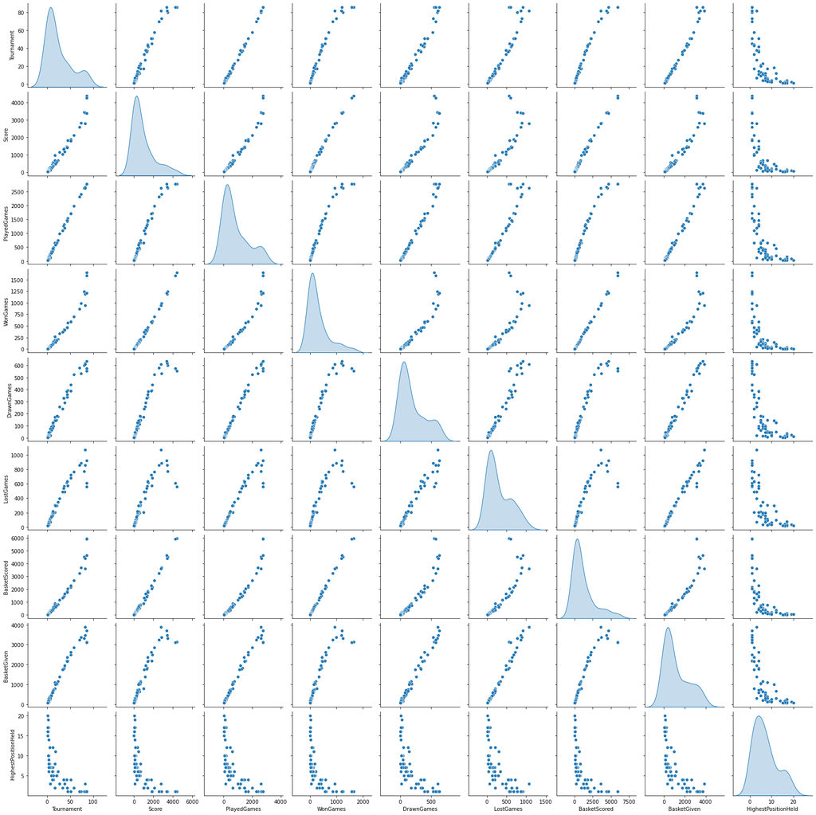

```python
sns.pairplot(bastketBall_Data, diag_kind='kde');
```

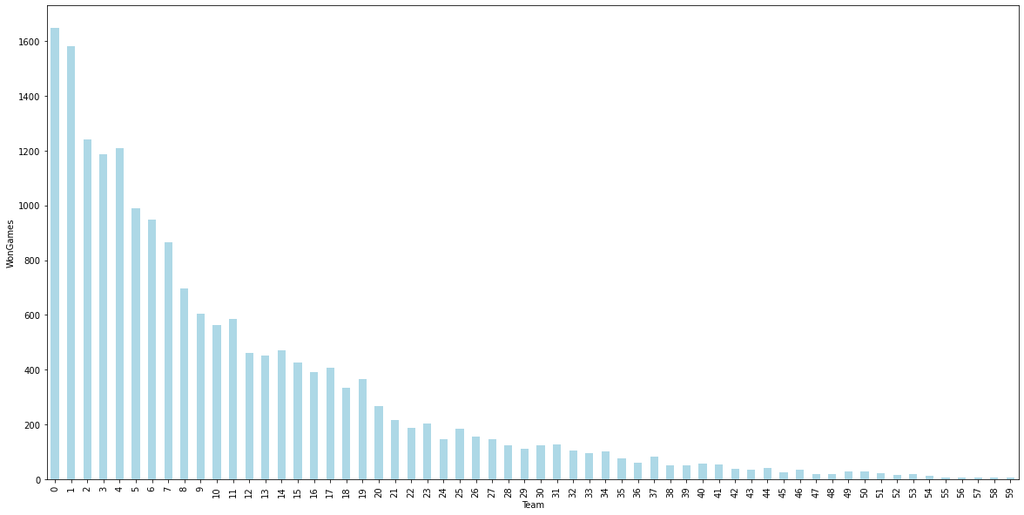

```python
#df.Country.value_counts().head(25).plot(kind = 'bar', edgecolor = 'black', color = 'lightblue', figsize = (15,5))
#plt.xlabel('Country')
#plt.ylabel('Number of users')
#plt.title('Top 25 countries in terms of userbase')
#plt.show()

bastketBall_Data.WonGames.plot(kind = 'bar',color='lightblue', figsize=(20,10))
plt.xlabel('Team')
plt.ylabel('WonGames')
plt.show();
```

**In the above graph, we can see which team has won most games. But we can also find out the probability of each teams to win a game.**

```python
p = {'Team': bastketBall_Data['Team'],'Winning Probability': bastketBall_Data['WonGames']/bastketBall_Data['PlayedGames']}
probabilityDf = pd.DataFrame(p)
```

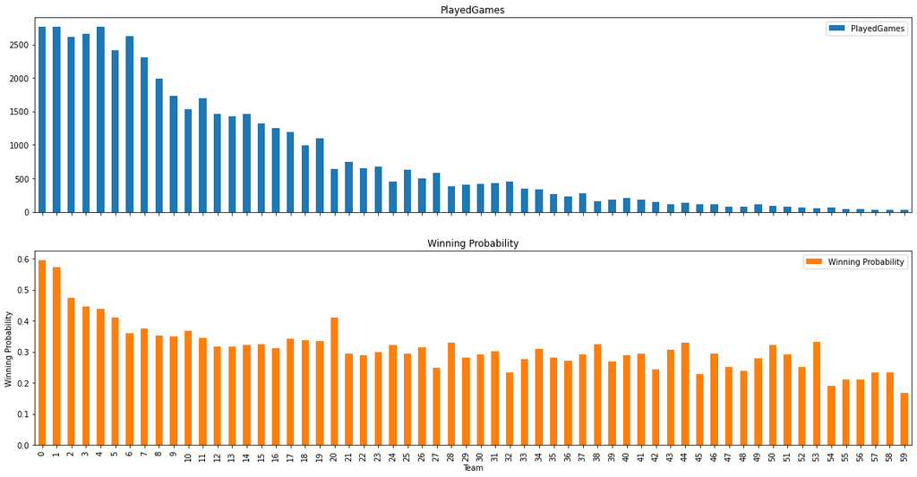

```python
df = pd.DataFrame({'PlayedGames': bastketBall_Data['PlayedGames'], 'Winning Probability': probabilityDf['Winning Probability']})

df.plot(kind = 'bar', figsize= (20,10), subplots = bool)
#probabilityDf['Winning Probability'].plot(kind = 'bar', color='lightblue', figsize= (20,10))
plt.xlabel('Team')
plt.ylabel('Winning Probability')
plt.show();
```

[output not shown]

```python
probabilityDf.describe()
```

|  | Winning Probability |
| --- | --- |
| count | 60.000000 |
| mean | 0.313648 |
| std | 0.078312 |
| min | 0.166667 |
| 25% | 0.276075 |
| 50% | 0.304917 |
| 75% | 0.335402 |
| max | 0.596307 |

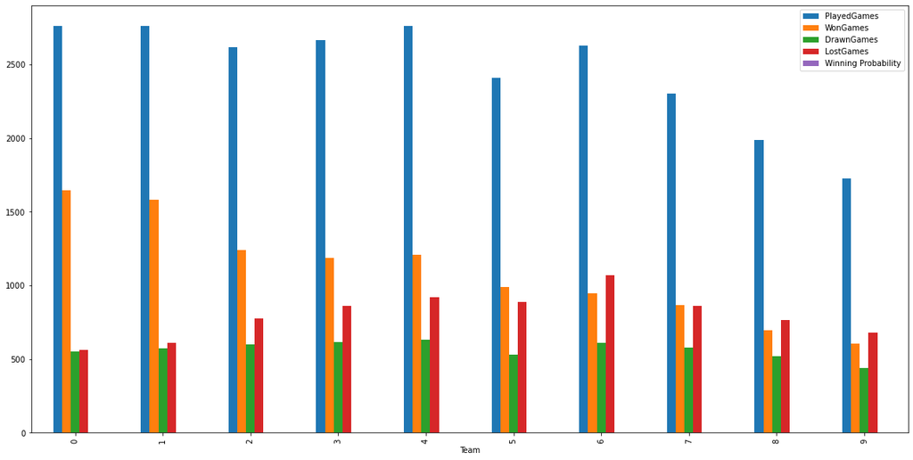

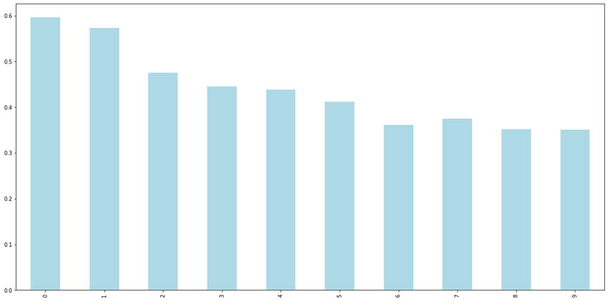

```python
df1 = pd.DataFrame({'PlayedGames': bastketBall_Data['PlayedGames'],
                   'WonGames': bastketBall_Data['WonGames'],
                   'DrawnGames': bastketBall_Data['DrawnGames'],
                   'LostGames': bastketBall_Data['LostGames'],
                   'Winning Probability': probabilityDf['Winning Probability']})

df1.sort_values('Winning Probability', ascending=False)

df1.head(10).plot(kind = 'bar', figsize= (20,10))
plt.xlabel('Team')
plt.show();
df1['Winning Probability'].head(10).plot(kind = 'bar', figsize= (20,10), color='lightblue')
plt.show();
```

```python
# will trim the first 4 characters of Team Launched column to get the proper year.
# Notice that in some of the data we have years like 1930-32 / 1930to40 or likewise

bastketBall_Data['TeamLaunch'] = bastketBall_Data['TeamLaunch'].str[:4]

bastketBall_Data['TeamLaunch'] = bastketBall_Data['TeamLaunch'].astype('int64')
bastketBall_Data
```

|  | Team | Tournament | Score | PlayedGames | WonGames | DrawnGames | LostGames | BasketScored | BasketGiven | TournamentChampion | Runner-up | TeamLaunch | HighestPositionHeld |
| --- | --- | --- | --- | --- | --- | --- | --- | --- | --- | --- | --- | --- | --- |
| 0 | Team 1 | 86 | 4385 | 2762 | 1647 | 552 | 563 | 5947 | 3140 | 33 | 23 | 1929 | 1 |
| 1 | Team 2 | 86 | 4262 | 2762 | 1581 | 573 | 608 | 5900 | 3114 | 25 | 25 | 1929 | 1 |
| 2 | Team 3 | 80 | 3442 | 2614 | 1241 | 598 | 775 | 4534 | 3309 | 10 | 8 | 1929 | 1 |
| 3 | Team 4 | 82 | 3386 | 2664 | 1187 | 616 | 861 | 4398 | 3469 | 6 | 6 | 1931 | 1 |
| 4 | Team 5 | 86 | 3368 | 2762 | 1209 | 633 | 920 | 4631 | 3700 | 8 | 7 | 1929 | 1 |
| 5 | Team 6 | 73 | 2819 | 2408 | 990 | 531 | 887 | 3680 | 3373 | 1 | 4 | 1934 | 1 |
| 6 | Team 7 | 82 | 2792 | 2626 | 948 | 608 | 1070 | 3609 | 3889 | - | - | 1929 | 3 |
| 7 | Team 8 | 70 | 2573 | 2302 | 864 | 577 | 861 | 3228 | 3230 | 2 | 3 | 1929 | 1 |
| 8 | Team 9 | 58 | 2109 | 1986 | 698 | 522 | 766 | 2683 | 2847 | - | 1 | 1939 | 2 |
| 9 | Team 10 | 51 | 1884 | 1728 | 606 | 440 | 682 | 2159 | 2492 | 1 | - | 1932 | 1 |
| 10 | Team 11 | 45 | 1814 | 1530 | 563 | 392 | 575 | 2052 | 2188 | 1 | 5 | 1941 | 1 |
| 11 | Team 12 | 51 | 1789 | 1698 | 586 | 389 | 723 | 2278 | 2624 | - | - | 1939 | 4 |
| 12 | Team 13 | 42 | 1471 | 1466 | 463 | 384 | 619 | 1767 | 2180 | - | - | 1948 | 4 |
| 13 | Team 14 | 44 | 1416 | 1428 | 453 | 336 | 639 | 1843 | 2368 | - | 1 | 1929 | 2 |
| 14 | Team 15 | 43 | 1389 | 1458 | 471 | 358 | 629 | 1753 | 2152 | - | 1 | 1944 | 2 |
| 15 | Team 16 | 37 | 1351 | 1318 | 426 | 327 | 565 | 1500 | 1834 | - | - | 1935 | 4 |
| 16 | Team 17 | 36 | 1314 | 1255 | 390 | 330 | 535 | 1421 | 1763 | - | - | 1949 | 4 |
| 17 | Team 18 | 38 | 1174 | 1192 | 408 | 292 | 492 | 1642 | 1951 | - | - | 1933 | 3 |
| 18 | Team 19 | 27 | 1148 | 988 | 333 | 256 | 399 | 1182 | 1371 | - | - | 1960 | 3 |
| 19 | Team 20 | 33 | 1020 | 1096 | 367 | 242 | 487 | 1347 | 1746 | - | 1 | 1951 | 2 |
| 20 | Team 21 | 17 | 970 | 646 | 266 | 172 | 208 | 892 | 789 | - | 1 | 1998 | 2 |
| 21 | Team 22 | 23 | 667 | 742 | 218 | 175 | 349 | 819 | 1157 | - | - | 1941 | 6 |
| 22 | Team 23 | 17 | 662 | 652 | 189 | 148 | 305 | 760 | 1088 | - | - | 1977 | 8 |
| 23 | Team 24 | 21 | 606 | 678 | 203 | 180 | 295 | 750 | 1022 | - | - | 1959 | 5 |
| 24 | Team 25 | 12 | 553 | 456 | 147 | 112 | 197 | 520 | 633 | - | - | 2004 | 6 |
| 25 | Team 26 | 20 | 538 | 628 | 184 | 149 | 295 | 716 | 1050 | - | - | 1935 | 5 |
| 26 | Team 27 | 13 | 510 | 494 | 155 | 128 | 211 | 619 | 744 | - | - | 1961 | 5 |
| 27 | Team 28 | 18 | 445 | 586 | 145 | 143 | 298 | 607 | 992 | - | - | 1940 | 11 |
| 28 | Team 29 | 12 | 421 | 380 | 125 | 81 | 174 | 458 | 623 | - | - | 1930 | 6 |
| 29 | Team 30 | 11 | 416 | 402 | 113 | 95 | 194 | 430 | 632 | - | - | 1963 | 6 |
| 30 | Team 31 | 12 | 375 | 423 | 123 | 102 | 198 | 422 | 581 | - | - | 1974 | 7 |
| 31 | Team 32 | 14 | 353 | 426 | 129 | 95 | 202 | 492 | 720 | - | - | 1943 | 4 |
| 32 | Team 33 | 12 | 343 | 448 | 104 | 127 | 217 | 393 | 662 | - | - | 1977 | 12 |
| 33 | Team 34 | 9 | 293 | 346 | 96 | 92 | 158 | 291 | 489 | - | - | 1987 | 7 |
| 34 | Team 35 | 11 | 285 | 334 | 103 | 79 | 152 | 419 | 588 | - | - | 1941 | 4 |
| 35 | Team 36 | 7 | 277 | 270 | 76 | 76 | 118 | 320 | 410 | - | - | 1991 | 7 |
| 36 | Team 37 | 6 | 242 | 228 | 62 | 56 | 110 | 244 | 366 | - | - | 2007 | 8 |
| 37 | Team 38 | 9 | 230 | 282 | 82 | 63 | 137 | 285 | 430 | - | - | 1962 | 5 |
| 38 | Team 39 | 4 | 190 | 160 | 52 | 45 | 63 | 199 | 241 | - | - | 1994 | 10 |
| 39 | Team 40 | 5 | 188 | 186 | 50 | 46 | 90 | 202 | 296 | - | - | 1978 | 8 |
| 40 | Team 41 | 6 | 168 | 204 | 59 | 50 | 95 | 216 | 310 | - | - | 1971 | 12 |
| 41 | Team 42 | 6 | 150 | 180 | 53 | 44 | 83 | 165 | 221 | - | - | 1963 | 7 |
| 42 | Team 43 | 4 | 148 | 152 | 37 | 37 | 78 | 155 | 253 | - | - | 1999 | 17 |
| 43 | Team 44 | 3 | 132 | 114 | 35 | 27 | 52 | 139 | 167 | - | - | 2014 | 10 |
| 44 | Team 45 | 7 | 107 | 130 | 43 | 21 | 66 | 227 | 308 | - | - | 1929 | 3 |
| 45 | Team 46 | 3 | 96 | 114 | 26 | 44 | 44 | 101 | 139 | - | - | 1990 | 9 |
| 46 | Team 47 | 4 | 91 | 116 | 34 | 16 | 66 | 181 | 295 | - | - | 1947 | 7 |
| 47 | Team 48 | 2 | 83 | 80 | 20 | 23 | 37 | 62 | 117 | - | - | 1996 | 17 |
| 48 | Team 49 | 2 | 81 | 80 | 19 | 24 | 37 | 70 | 115 | - | - | 1995 | 19 |
| 49 | Team 50 | 4 | 76 | 108 | 30 | 16 | 62 | 145 | 252 | - | - | 1945 | 10 |
| 50 | Team 51 | 3 | 71 | 90 | 29 | 13 | 48 | 121 | 183 | - | - | 1953 | 14 |
| 51 | Team 52 | 4 | 56 | 72 | 21 | 14 | 37 | 153 | 184 | - | - | 1929 | 6 |
| 52 | Team 53 | 2 | 52 | 68 | 17 | 18 | 33 | 71 | 116 | - | - | 1979 | 10 |
| 53 | Team 54 | 3 | 42 | 54 | 18 | 6 | 30 | 97 | 131 | - | - | 1929 | 8 |
| 54 | Team 55 | 2 | 40 | 68 | 13 | 14 | 41 | 70 | 182 | - | - | 1950 | 16 |
| 55 | Team 56 | 1 | 35 | 38 | 8 | 11 | 19 | 36 | 55 | - | - | 2016 | 17 |
| 56 | Team 57 | 1 | 34 | 38 | 8 | 10 | 20 | 38 | 66 | - | - | 2009 | 20 |
| 57 | Team 58 | 1 | 22 | 30 | 7 | 8 | 15 | 37 | 57 | - | - | 1956 | 16 |
| 58 | Team 59 | 1 | 19 | 30 | 7 | 5 | 18 | 51 | 85 | - | - | 1951 | 16 |
| 59 | Team 60 | 1 | 14 | 30 | 5 | 4 | 21 | 34 | 65 | - | - | 1955 | 15 |

```python
minYear = bastketBall_Data['TeamLaunch'].min()
```

```python
bastketBall_Data[bastketBall_Data['TeamLaunch'] == minYear]
```

|  | Team | Tournament | Score | PlayedGames | WonGames | DrawnGames | LostGames | BasketScored | BasketGiven | TournamentChampion | Runner-up | TeamLaunch | HighestPositionHeld |
| --- | --- | --- | --- | --- | --- | --- | --- | --- | --- | --- | --- | --- | --- |
| 0 | Team 1 | 86 | 4385 | 2762 | 1647 | 552 | 563 | 5947 | 3140 | 33 | 23 | 1929 | 1 |
| 1 | Team 2 | 86 | 4262 | 2762 | 1581 | 573 | 608 | 5900 | 3114 | 25 | 25 | 1929 | 1 |
| 2 | Team 3 | 80 | 3442 | 2614 | 1241 | 598 | 775 | 4534 | 3309 | 10 | 8 | 1929 | 1 |
| 4 | Team 5 | 86 | 3368 | 2762 | 1209 | 633 | 920 | 4631 | 3700 | 8 | 7 | 1929 | 1 |
| 6 | Team 7 | 82 | 2792 | 2626 | 948 | 608 | 1070 | 3609 | 3889 | - | - | 1929 | 3 |
| 7 | Team 8 | 70 | 2573 | 2302 | 864 | 577 | 861 | 3228 | 3230 | 2 | 3 | 1929 | 1 |
| 13 | Team 14 | 44 | 1416 | 1428 | 453 | 336 | 639 | 1843 | 2368 | - | 1 | 1929 | 2 |
| 44 | Team 45 | 7 | 107 | 130 | 43 | 21 | 66 | 227 | 308 | - | - | 1929 | 3 |
| 51 | Team 52 | 4 | 56 | 72 | 21 | 14 | 37 | 153 | 184 | - | - | 1929 | 6 |
| 53 | Team 54 | 3 | 42 | 54 | 18 | 6 | 30 | 97 | 131 | - | - | 1929 | 8 |

1. Please include any improvements or suggestions to the association management on quality, quantity, variety, velocity, veracity etc. on the data points collected by the association to perform a better data analysis in future.
- The quaity of the data can be improved to some extent. Now we can see that their are few columns like Tournament Champions, Runner up where in place where the teams have not achieved and significant place, - is used as a data.
- which can be changed to contain 0
- Almost all the rows contains data, so we can say it is a good data, except for the above point.

# Part Three

**CONTEXT:** Company X is a EU online publisher focusing on the startups industry. The company specifically reports on the business related to technology news, analysis of emerging trends and profiling of new tech businesses and products. Their event i.e. Startup Battlefield is the world’s pre-eminent startup competition. Startup Battlefield features 15-30 top early stage startups pitching top judges in front of a vast live audience, present in person and online.  
**DATA DESCRIPTION:** CompanyX_EU.csv - Each row in the dataset is a Start-up company and the columns describe the company.  
**ATTRIBUTE INFORMATION:**

1. Startup: Name of the company
2. Product: Actual product
3. Funding: Funds raised by the company in USD
4. Event: The event the company participated in
5. Result: Described by Contestant, Finalist, Audience choice, Winner or Runner up
6. OperatingState: Current status of the company, Operating ,Closed, Acquired or IPO

**1. Data warehouse:** Read the CSV file.

```python
companyX_Data = pd.read_csv("CompanyX_EU.csv")
print("Total number of rows in companyX_Data: ",len(companyX_Data))
companyX_Data.describe()
```

```
Total number of rows in companyX_Data:  662
```

|  | Startup | Product | Funding | Event | Result | OperatingState |
| --- | --- | --- | --- | --- | --- | --- |
| count | 662 | 656 | 448 | 662 | 662 | 662 |
| unique | 662 | 656 | 240 | 26 | 5 | 4 |
| top | InsideDNA | icharts.net | $1M | TC50 2008 | Contestant | Operating |
| freq | 1 | 1 | 17 | 52 | 488 | 465 |

From above count values we can see that their are certain rows like Funding and Product conatin null values.  
We will process null values later below

```python
companyX_Data
```

|  | Startup | Product | Funding | Event | Result | OperatingState |
| --- | --- | --- | --- | --- | --- | --- |
| 0 | 2600Hz | 2600hz.com | NaN | Disrupt SF 2013 | Contestant | Operating |
| 1 | 3DLT | 3dlt.com | $630K | Disrupt NYC 2013 | Contestant | Closed |
| 2 | 3DPrinterOS | 3dprinteros.com | NaN | Disrupt SF 2016 | Contestant | Operating |
| 3 | 3Dprintler | 3dprintler.com | $1M | Disrupt NY 2016 | Audience choice | Operating |
| 4 | 42 Technologies | 42technologies.com | NaN | Disrupt NYC 2013 | Contestant | Operating |
| ... | ... | ... | ... | ... | ... | ... |
| 657 | Zivity | zivity.com | $8M | TC40 2007 | Contestant | Operating |
| 658 | Zmorph | zmorph3d.com | $1M | - | Audience choice | Operating |
| 659 | Zocdoc | zocdoc.com | $223M | TC40 2007 | Contestant | Operating |
| 660 | Zula | zulaapp.com | $3.4M | Disrupt SF 2013 | Audience choice | Operating |
| 661 | Zumper | zumper.com | $31.5M | Disrupt SF 2012 | Finalist | Operating |

662 rows × 6 columns

**2. Data exploration:**  
• Check the datatypes of each attribute.

```python
companyX_Data.dtypes
```

```
Startup           object
Product           object
Funding           object
Event             object
Result            object
OperatingState    object
dtype: object
```

We can see that all the columns are of Object type

But funding column should be for integer type, if we want to perform any calculation on it. We can treat that later

• Check for null values in the attributes

```python
companyX_Data.isna().sum()
```

```
Startup             0
Product             6
Funding           214
Event               0
Result              0
OperatingState      0
dtype: int64
```

We can see that Funding column has a lot of missing data.

**3. Data preprocessing & visualisation:**  
Lets Drop the null values.

```python
df = companyX_Data.dropna().copy(deep=True)
df.isna().sum()
```

```
Startup           0
Product           0
Funding           0
Event             0
Result            0
OperatingState    0
dtype: int64
```

Let's now convert the ‘Funding’ features to a numerical value.

```python
df['Funding']
```

```
1       $630K
3         $1M
5      $19.3M
6        $29M
10      $1.8M
        ...
657       $8M
658       $1M
659     $223M
660     $3.4M
661    $31.5M
Name: Funding, Length: 446, dtype: object
```

We can see that funding data contain Dollar sign and K/M abbreviations mentioning whether the value is in thousands or million.  
To keep the unit same in all the data, lets add the column showing funds_in_million

```python
df.loc[:,'Funds_in_million'] = df['Funding'].apply(lambda x: float(x[1:-1])/1000 if x[-1] == 'K' else (float(x[1:-1])*1000 if x[-1] == 'B' else float(x[1:-1])))
df
```

|  | Startup | Product | Funding | Event | Result | OperatingState | Funds_in_million |
| --- | --- | --- | --- | --- | --- | --- | --- |
| 1 | 3DLT | 3dlt.com | $630K | Disrupt NYC 2013 | Contestant | Closed | 0.63 |
| 3 | 3Dprintler | 3dprintler.com | $1M | Disrupt NY 2016 | Audience choice | Operating | 1.00 |
| 5 | 5to1 | 5to1.com | $19.3M | TC50 2009 | Contestant | Acquired | 19.30 |
| 6 | 8 Securities | 8securities.com | $29M | Disrupt Beijing 2011 | Finalist | Operating | 29.00 |
| 10 | AdhereTech | adheretech.com | $1.8M | Hardware Battlefield 2014 | Contestant | Operating | 1.80 |
| ... | ... | ... | ... | ... | ... | ... | ... |
| 657 | Zivity | zivity.com | $8M | TC40 2007 | Contestant | Operating | 8.00 |
| 658 | Zmorph | zmorph3d.com | $1M | - | Audience choice | Operating | 1.00 |
| 659 | Zocdoc | zocdoc.com | $223M | TC40 2007 | Contestant | Operating | 223.00 |
| 660 | Zula | zulaapp.com | $3.4M | Disrupt SF 2013 | Audience choice | Operating | 3.40 |
| 661 | Zumper | zumper.com | $31.5M | Disrupt SF 2012 | Finalist | Operating | 31.50 |

446 rows × 7 columns

```python
df.dtypes
```

```
Startup              object
Product              object
Funding              object
Event                object
Result               object
OperatingState       object
Funds_in_million    float64
dtype: object
```

Now when we need to process funding, we can use funds_in_millon column

Plot box plot for funds in million

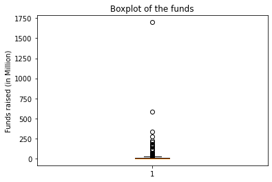

```python
plot = plt.boxplot(df.Funds_in_million)
plt.title('Boxplot of the funds')
plt.ylabel("Funds raised (in Million)")

plt.show();
```

Get the lower fence and upper fence from the box plot.

```python
IQR = df.quantile(0.75) - df.quantile(0.25)
IQR

upperfence = df.quantile(0.75) + (1.5 * IQR)
lowerfence = df.quantile(0.25) - (1.5 *IQR)

print("LowerFence: %2.2f" %lowerfence, " and UpperFence: %2.2f" %upperfence)

upper_fence = plot['caps'][1].get_data()[1][1]   # we can also use the values from the box plot itself to get the upper fence
upper_fence
```

```
LowerFence: -12.35  and UpperFence: 22.57
```

```
22.0
```

Check number of outliers greater than upper fence.

```python
print("Number of outliers greater than upper fence: ",len(df[df['Funds_in_million'] > upper_fence]))
```

```
Number of outliers greater than upper fence:  60
```

Drop the values that are greater than upper fence.

```python
df.drop(df[df.Funds_in_million > upper_fence].index, inplace = True)
```

Plot the box plot after dropping the values.

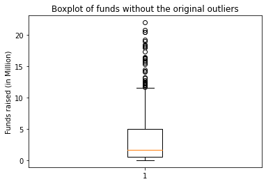

```python
plot = plt.boxplot(df.Funds_in_million)
plt.title('Boxplot of funds without the original outliers')
plt.ylabel("Funds raised (in Million)")
plt.show();
```

```python
df.describe()
```

|  | Funds_in_million |
| --- | --- |
| count | 386.00000 |
| mean | 3.72514 |
| std | 4.73236 |
| min | 0.00500 |
| 25% | 0.60000 |
| 50% | 1.70000 |
| 75% | 5.00000 |
| max | 22.00000 |

- 75% of the companies have less than 5 million raised funds, the max however is 22
- Even after removing the outliers, the data is pretty heavily skewed

Check frequency of the OperatingState features classes.

```python
df.OperatingState.value_counts()
```

```
Operating    275
Closed        56
Acquired      55
Name: OperatingState, dtype: int64
```

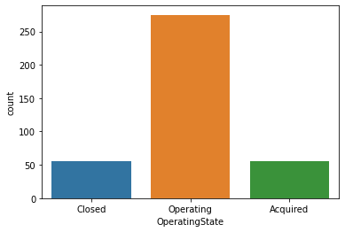

```python
sns.countplot(x=df.OperatingState)
```

Plot a distribution plot for Funds in million.

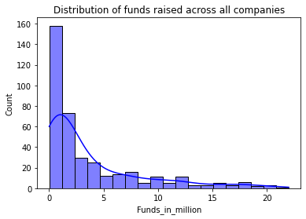

```python
sns.histplot(df.Funds_in_million, kde=True , color='blue')
plt.title('Distribution of funds raised across all companies')
plt.show();
```

Plot distribution plots for companies still operating and companies that closed.

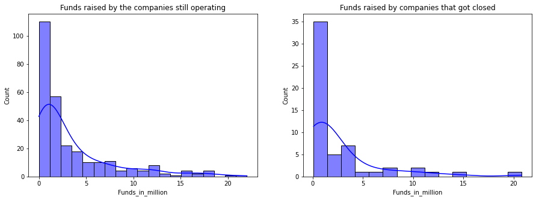

```python
fig, ax = plt.subplots(1, 2)

fig.set_figheight(5)
fig.set_figwidth(15)

sns.histplot(df.loc[df.OperatingState == 'Operating', 'Funds_in_million'], ax = ax[0], kde = True, color = 'blue')
sns.histplot(df.loc[df.OperatingState =='Closed', 'Funds_in_million'], ax = ax[1], kde = True, color = 'blue')

ax[0].set_title('Funds raised by the companies still operating')
ax[1].set_title('Funds raised by companies that got closed')
plt.show();
```

- Visually the difference between the funds raised by Operating and closed compaies are quiet similar
- The data here is not normalized yet. So, we can take sample data and work on it assuming it is normalized

**Null hypothesis (Ho)** : There is no difference between the two means

**Alternate hypothesis (Ha)** : There is significant difference between the two means

```python
from statsmodels.stats.weightstats import ztest
```

```python
sample1 = df.loc[df.OperatingState == 'Operating', 'Funds_in_million']
sample2 = df.loc[df.OperatingState =='Closed', 'Funds_in_million']

alpha = 0.05   # Let's consider a significance level of 5%

test_statistic, p_value = ztest(sample1, sample2)

p_value
```

```
0.1922631485716917
```

- Here, as the p_value, 0.1923 > 0.05, we fail to reject the null hypothesis as the difference is not significant

Calculate percentage of winners that are still operating and percentage of contestants that are still operating

```python
df1 = companyX_Data.copy(deep = True)
df1.head()
```

|  | Startup | Product | Funding | Event | Result | OperatingState |
| --- | --- | --- | --- | --- | --- | --- |
| 0 | 2600Hz | 2600hz.com | NaN | Disrupt SF 2013 | Contestant | Operating |
| 1 | 3DLT | 3dlt.com | $630K | Disrupt NYC 2013 | Contestant | Closed |
| 2 | 3DPrinterOS | 3dprinteros.com | NaN | Disrupt SF 2016 | Contestant | Operating |
| 3 | 3Dprintler | 3dprintler.com | $1M | Disrupt NY 2016 | Audience choice | Operating |
| 4 | 42 Technologies | 42technologies.com | NaN | Disrupt NYC 2013 | Contestant | Operating |

```python
winners = df1[df1.Result == 'Winner']
contestants = df1[df1.Result == 'Contestant']

len(winners)
```

```
26
```

```python
df1 = df1[df1.OperatingState == 'Operating']
df1
```

|  | Startup | Product | Funding | Event | Result | OperatingState |
| --- | --- | --- | --- | --- | --- | --- |
| 0 | 2600Hz | 2600hz.com | NaN | Disrupt SF 2013 | Contestant | Operating |
| 2 | 3DPrinterOS | 3dprinteros.com | NaN | Disrupt SF 2016 | Contestant | Operating |
| 3 | 3Dprintler | 3dprintler.com | $1M | Disrupt NY 2016 | Audience choice | Operating |
| 4 | 42 Technologies | 42technologies.com | NaN | Disrupt NYC 2013 | Contestant | Operating |
| 6 | 8 Securities | 8securities.com | $29M | Disrupt Beijing 2011 | Finalist | Operating |
| ... | ... | ... | ... | ... | ... | ... |
| 657 | Zivity | zivity.com | $8M | TC40 2007 | Contestant | Operating |
| 658 | Zmorph | zmorph3d.com | $1M | - | Audience choice | Operating |
| 659 | Zocdoc | zocdoc.com | $223M | TC40 2007 | Contestant | Operating |
| 660 | Zula | zulaapp.com | $3.4M | Disrupt SF 2013 | Audience choice | Operating |
| 661 | Zumper | zumper.com | $31.5M | Disrupt SF 2012 | Finalist | Operating |

465 rows × 6 columns

```python
df1.Result.value_counts()
```

```
Contestant         332
Finalist            61
Audience choice     32
Runner up           21
Winner              19
Name: Result, dtype: int64
```

```python
winners_Operating = df1[df1.Result == 'Winner']
contestants_Operating = df1[df1.Result == 'Contestant']
```

```python
print("Percentage of winners that are still operating: %2.2f" %(len(winners_Operating)/len(winners)*100), "%")

print("Percentage of winners that are still operating: %2.2f" %(len(contestants_Operating)/len(contestants)*100), "%")
```

[output not shown]

Write your hypothesis comparing the proportion of companies that are operating between winners and contestants:

**Null hyputhesis (Ho)**: The proportion of companies that are operating is the same in both categories - winners and contestants

**Alternative hypothesis (Ha)**: The proportion of companies that are operating is significantly different from each other, among the two categories

```python
from statsmodels.stats.proportion import proportions_ztest

winners_OperatingNo = winners_Operating.value_counts().sum()
contestants_OperatingNo = contestants_Operating.value_counts().sum()
winnersNo = winners.value_counts().sum()
contestantsNo = contestants.value_counts().sum()

test_statistic, p_value = proportions_ztest([contestants_OperatingNo, winners_OperatingNo], [contestantsNo, winnersNo])

p_value
```

```
0.7231510556194248
```

- We fail to reject the null hypothesis here as p_value, 0.72 > 0.05

Select only the Event that has disrupt keyword from 2013 onwards.

```python
df1
```

|  | Startup | Product | Funding | Event | Result | OperatingState |
| --- | --- | --- | --- | --- | --- | --- |
| 0 | 2600Hz | 2600hz.com | NaN | Disrupt SF 2013 | Contestant | Operating |
| 2 | 3DPrinterOS | 3dprinteros.com | NaN | Disrupt SF 2016 | Contestant | Operating |
| 3 | 3Dprintler | 3dprintler.com | $1M | Disrupt NY 2016 | Audience choice | Operating |
| 4 | 42 Technologies | 42technologies.com | NaN | Disrupt NYC 2013 | Contestant | Operating |
| 6 | 8 Securities | 8securities.com | $29M | Disrupt Beijing 2011 | Finalist | Operating |
| ... | ... | ... | ... | ... | ... | ... |
| 657 | Zivity | zivity.com | $8M | TC40 2007 | Contestant | Operating |
| 658 | Zmorph | zmorph3d.com | $1M | - | Audience choice | Operating |
| 659 | Zocdoc | zocdoc.com | $223M | TC40 2007 | Contestant | Operating |
| 660 | Zula | zulaapp.com | $3.4M | Disrupt SF 2013 | Audience choice | Operating |
| 661 | Zumper | zumper.com | $31.5M | Disrupt SF 2012 | Finalist | Operating |

465 rows × 6 columns

```python
# Selecting only the events which has Disrupt keyword in it and are onwards the year 2013

events = df[df.Event.apply(lambda x: 'Disrupt' in x and int(x[-4:]) > 2012)].Event  # all the events of relevance
events
```

```
1         Disrupt NYC 2013
3          Disrupt NY 2016
13         Disrupt SF 2015
14     Disrupt London 2016
16         Disrupt SF 2015
              ...
635        Disrupt NY 2015
641       Disrupt NYC 2013
642        Disrupt SF 2014
646    Disrupt London 2015
660        Disrupt SF 2013
Name: Event, Length: 185, dtype: object
```

```python
#dividing the companies across in NY, SF and EU

NY_events = df.loc[events[events.apply(lambda x: 'NY' in x)].index, 'Funds_in_million']
SF_events = df.loc[events[events.apply(lambda x: 'SF' in x)].index, 'Funds_in_million']
EU_events = df.loc[events[events.apply(lambda x: 'EU' in x or 'London' in x)].index, 'Funds_in_million']
print(len(NY_events), len(SF_events), len(EU_events))
```

```
71 74 40
```

- Each of the three above variables hold the amount of funds with respect to the Cities where the even was organised
- The sample sizes are different across the three categories and it is okay to perform ANOVA on samples of different sizes

**Null Hypothesis(Ho)**: Average funds raised by companies across three cities are the same

**Alternative Hypothesis(Ha)**: Average funds raised by companies across three cities are the different

```python
from scipy.stats import f_oneway


stat, p_value = f_oneway(NY_events, SF_events, EU_events)

p_value
```

```
0.6283904595058631
```

- We fail to reject the null hypothesis here as p_value, 0.62 > 0.05
- Funds raised by the companies across three regions is same

Plot the distribution plot comparing the 3 city events.

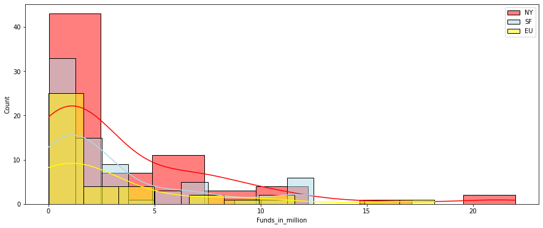

```python
plt.figure(figsize=(15,6))
sns.histplot(NY_events, color = 'red', label = 'NY', kde=True)
sns.histplot(SF_events, color = 'lightblue', label = 'SF', kde = True)
sns.histplot(EU_events, color = 'yellow', label = 'EU', kde = True)
plt.legend()
plt.show();
```

- Visually as well the distribution of events look almost similar across all three regions
- Modes and skewness also looks same for all three regions
1. Write your observations on improvements or suggestions on quality, quantity, variety, velocity, veracity etc. on the data points collected to perform a better data analysis.
- There is a high number of null values in Funding Column, due to ehich e ha to drop a lot of data.
- There are high number of outliers as well, which hampers the statistical analysis